# Diff_exp_linear_mixed_model_limma

```r
colnames(txi$counts)= phenotype_no_AJ_5$Col7
head(txi$counts)
```

```
##                     AB_1      AB_2     AC_1      AC_2     AC_3      AC_4
## ENSG00000000003    9.686    40.000   31.000    23.000   37.000    36.000
## ENSG00000000005    0.000     0.000    0.000     0.000    0.000     0.000
## ENSG00000000419  627.006  1049.923  598.366   751.120  812.225   768.285
## ENSG00000000457  646.831   855.571  535.655   858.096  696.254   808.045
## ENSG00000000460  177.073   209.020   98.788   130.366  161.739   168.166
## ENSG00000000938 8855.411 12619.451 6528.085 13055.470 7487.972 14725.944
##                     AD_1     AE_1     AE_2     AE_3     AE_4     AF_1      AF_2
## ENSG00000000003    5.000   13.000   31.000   34.000   30.000   13.000    22.000
## ENSG00000000005    0.000    0.000    0.000    0.000    0.000    0.000     0.000
## ENSG00000000419  433.536  369.374  464.879  481.999  653.998  398.337   731.610
## ENSG00000000457  425.544  335.027  590.913  468.493  515.839  428.638   736.496
## ENSG00000000460  116.569   63.992  113.585  117.506   77.161   88.361   255.428
## ENSG00000000938 7221.245 6342.936 9238.872 6793.608 7460.419 5194.022 15089.078
##                      AF_3      AF_4     AF_5     AF_6     AF_7     AF_8
## ENSG00000000003    21.105    25.000    2.394   23.000   28.000   23.001
## ENSG00000000005     0.000     0.000    0.000    0.000    0.000    0.000
## ENSG00000000419   643.662   788.091  396.492  339.349  477.602  544.202
## ENSG00000000457   455.885   724.691  416.737  390.823  493.326  491.863
## ENSG00000000460    69.115   187.769   63.576  111.040  133.717  105.481
## ENSG00000000938 11238.692 10753.382 5581.523 4562.667 6545.808 6283.066
##                     AG_1      AG_2      AG_3     AG_4      AG_5     AG_6
## ENSG00000000003    4.000    25.000    26.000   20.000    11.000   27.000
## ENSG00000000005    0.000     0.000     0.000    0.000     0.000    0.000
## ENSG00000000419  378.330   847.347   798.057  682.000   861.876  652.094
## ENSG00000000457  359.592   814.067   735.103  699.460   979.660  664.234
## ENSG00000000460   72.818   216.788   205.897  139.548   213.396  160.142
## ENSG00000000938 6341.054 11558.867 10485.366 7872.200 11229.796 6375.427
##                     AG_7     AG_8      AH_1      AH_2      AH_3      AH_4
## ENSG00000000003   34.000   20.000    21.000    22.000    16.000    26.000
## ENSG00000000005    0.000    0.000     0.000     0.000     0.000     0.000
## ENSG00000000419  667.959  793.149   438.041   571.555   471.055   674.338
## ENSG00000000457  674.110  815.073   516.458   608.540   423.657   621.109
## ENSG00000000460  147.890  184.927   114.009   160.710   132.502   150.413
## ENSG00000000938 9760.187 8207.143 10215.104 11839.937 10118.932 12975.767
##                      AH_5      AH_6      AH_7      AH_8     AJ_1     AJ_2
## ENSG00000000003    20.000    43.000    14.000    38.993   44.000   50.000
## ENSG00000000005     0.000     0.000     0.000     0.000    0.000    0.000
## ENSG00000000419   835.019   944.825   679.627  1147.000  672.000  996.101
## ENSG00000000457   805.009   956.705   702.434   895.850  614.242  788.650
## ENSG00000000460   220.148   273.034   179.326   305.357  107.759  158.821
## ENSG00000000938 11427.849 16835.969 13011.581 16952.911 7553.762 8561.322
##                     AJ_3      AJ_4      AJ_6      AJ_7      AJ_8
## ENSG00000000003   13.000    53.000    41.000    23.000    23.000
## ENSG00000000005    0.000     0.000     0.000     0.000     0.000
## ENSG00000000419  314.506   876.301   987.226  1004.002  1003.998
## ENSG00000000457  278.006   588.880   800.510   978.346   978.347
## ENSG00000000460   58.994    89.675   236.599   156.979   156.979
## ENSG00000000938 3445.822 13347.887 11965.560 12000.878 12000.870
```

```r
## model fit for
#dds <- DESeqDataSetFromTximport(txi = txi, colData = phenotype_no_AJ_5, design = ~ 1)
#dds <- DESeq(dds)
#dispersions <- setNames(dispersions(dds), rownames(txi$counts))

#head(dispersions)
```

Size Factors

```r
#sizeFactors <- estimateSizeFactorsForMatrix(txi$counts)  # normalise to mean = 1

#head(sizeFactors)
```

```r
## Nothing here

#dds = dds[1:1000,]
```

Limma Analysis Limma has a built-in approach for analyzing repeated measures data using duplicateCorrelation(). The model can handle a single random effect, and forces the magnitude of the random effect to be the same across all genes.

First process wit edgeR

```r
library(edgeR)
# filter genes by number of counts
isexpr <- rowSums(cpm(txi$counts) > 0.5) >= 5

# Standard usage of limma/voom
dge <- DGEList(txi$counts[isexpr, ])
dge <- calcNormFactors(dge)

# make this vignette faster by analyzing a subset of genes
#dge <- dge[1:1000, ]
```

Limma analysis Limma has a built-in approach for analyzing repeated measures data using duplicateCorrelation(). The model can handle a single random effect, and forces the magnitude of the random effect to be the same across all genes.

```r
# apply duplicateCorrelation is two rounds
design <- model.matrix(~ Combined_var + BMI_c + Age_c + Gender, phenotype_no_AJ_5)
phenotype_no_AJ_5$ID = as.character(phenotype_no_AJ_5$ID)
phenotype_no_AJ_5$Combined_var = as.factor(phenotype_no_AJ_5$Combined_var)
vobj_tmp <- voom(dge, design, plot = FALSE)
dupcor <- duplicateCorrelation(vobj_tmp, design, block = phenotype_no_AJ_5$ID)

# run voom considering the duplicateCorrelation results
# in order to compute more accurate precision weights
# Otherwise, use the results from the first voom run
vobj <- voom(dge, design, plot = FALSE, block = phenotype_no_AJ_5$ID, correlation = dupcor$consensus)

# Estimate linear mixed model with a single variance component
# Fit the model for each gene,
dupcor <- duplicateCorrelation(vobj, design, block = phenotype_no_AJ_5$ID)

# But this step uses only the genome-wide average for the random effect
fitDupCor <- lmFit(vobj, design, block = phenotype_no_AJ_5$Individual, correlation = dupcor$consensus)

# Fit Empirical Bayes for moderated t-statistics
fitDupCor <- eBayes(fitDupCor)
```

Dream Analysis The dream method replaces 4 core functions of limma with a linear mixed model.

voomWithDreamWeights() replaces voom() to estimate precision weights dream() replaces lmFit() to estimate regression coefficients. variancePartition::eBayes() replaces limma::eBayes() to apply empircal Bayes shrinkage on linear mixed models. variancePartition::topTable() replaces limma::topTable() to give seamless access to results from dream(). For models with only fixed effects, variancePartition::eBayes(), and variancePartition::topTable() work seamlessly and give results equivalent to the limma functions with the same name. From the user perspective, the dream() workflow is the same as limma since the statistical differences are handled behind the scenes.

```r
# Specify parallel processing parameters
# this is used implicitly by dream() to run in parallel
rownames(phenotype_no_AJ_5) = phenotype_no_AJ_5$Col7
library(BiocParallel)
library(variancePartition)
param <- SnowParam(4, "SOCK", progressbar = TRUE)

# The variable to be tested must be a fixed effect
form <- ~ Combined_var + BMI_c + Age_c + Gender +  (1 | ID)

# estimate weights using linear mixed model of dream
vobjDream <- voomWithDreamWeights(dge, form, phenotype_no_AJ_5, BPPARAM = param)
```

```
## iteration:
```

```
## 1234
```

```r
# Fit the dream model on each gene
# For the hypothesis testing, by default,
# dream() uses the KR method for <= 20 samples,
# otherwise it uses the Satterthwaite approximation
fitmm <- dream(vobjDream, form, phenotype_no_AJ_5)
fitmm <- eBayes(fitmm)
```

# CHeck design matrix

```r
head(fitmm$design, 3)
```

```
##      (Intercept) Combined_varT0_Coconut_oil Combined_varT0_Corn_oil
## AB_1           1                          0                       1
## AB_2           1                          0                       0
## AC_1           1                          0                       0
##      Combined_varT0_Flaxseed_oil Combined_varT4_Butter
## AB_1                           0                     0
## AB_2                           0                     0
## AC_1                           0                     0
##      Combined_varT4_Coconut_oil Combined_varT4_Corn_oil
## AB_1                          0                       0
## AB_2                          0                       1
## AC_1                          0                       0
##      Combined_varT4_Flaxseed_oil      BMI_c     Age_c Gender2
## AB_1                           0  1.2596683 0.3374016       0
## AB_2                           0  1.2596683 0.3374016       0
## AC_1                           0 -0.5478646 0.7295170       1
```

```r
 #Get results of hypothesis test on coefficients of interest
topTable(fitmm, coef = "Combined_varT4_Corn_oil", number = 3)
```

```
##                      logFC   AveExpr         t      P.Value    adj.P.Val
## ENSG00000234258 -0.9774163 -3.689367 -8.550461 2.011393e-09 3.327246e-05
## ENSG00000204619 -0.4576426 -2.520658 -7.225593 5.898854e-08 4.878942e-04
## ENSG00000204257  0.8299468 -2.641333  5.813926 2.650675e-06 1.461582e-02
##                        B     z.std
## ENSG00000234258 5.930133 -5.996884
## ENSG00000204619 3.755371 -5.421840
## ENSG00000204257 1.981084  4.696183
```

Using contrasts to compare coefficients We can also perform a hypothesis test of the difference between two or more coefficients by using a contrast matrix. The contrasts are evaluated at the time of the model fit and the results can be extracted with topTable(). This behaves like makeContrasts() and contrasts.fit() in limma.

Multiple contrasts can be evaluated at the same time, in order to save computation time. Make sure to inspect your contrast matrix to confirm it is testing what you intend.

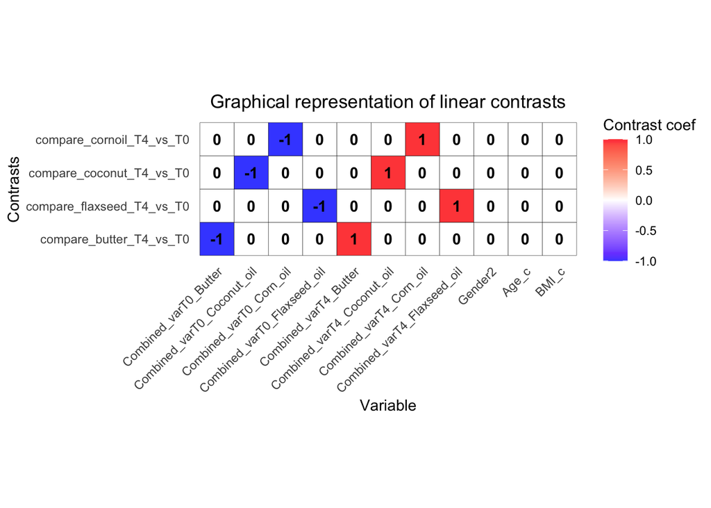

```r
phenotype_no_AJ_5$Combined_var = as.factor(phenotype_no_AJ_5$Combined_var)
form <- ~ 0 + Combined_var + Gender +  Age_c + BMI_c + (1 | ID)

L <- makeContrastsDream(form, phenotype_no_AJ_5,
  contrasts = c(
    compare_butter_T4_vs_T0 = "Combined_varT4_Butter - Combined_varT0_Butter",
    compare_flaxseed_T4_vs_T0 = "Combined_varT4_Flaxseed_oil - Combined_varT0_Flaxseed_oil",
    compare_coconut_T4_vs_T0 =  "Combined_varT4_Coconut_oil - Combined_varT0_Coconut_oil",
    compare_cornoil_T4_vs_T0 = "Combined_varT4_Corn_oil - Combined_varT0_Corn_oil"
  )
)

# Visualize contrast matrix
plotContrasts(L)
```

fit model with contrasts

```r
# fit dream model with contrasts
fit_model <- dream(vobjDream, form, phenotype_no_AJ_5, L)
fit_model <- eBayes(fit_model)

# get names of available coefficients and contrasts for testing
colnames(fit_model)
```

```
##  [1] "compare_butter_T4_vs_T0"     "compare_flaxseed_T4_vs_T0"
##  [3] "compare_coconut_T4_vs_T0"    "compare_cornoil_T4_vs_T0"
##  [5] "Combined_varT0_Butter"       "Combined_varT0_Coconut_oil"
##  [7] "Combined_varT0_Corn_oil"     "Combined_varT0_Flaxseed_oil"
##  [9] "Combined_varT4_Butter"       "Combined_varT4_Coconut_oil"
## [11] "Combined_varT4_Corn_oil"     "Combined_varT4_Flaxseed_oil"
## [13] "Gender2"                     "Age_c"
## [15] "BMI_c"
```

```r
cornoil_deg_res=topTable(fit_model, coef = c("compare_cornoil_T4_vs_T0"), number = 16542)
butter_deg_res=topTable(fit_model, coef = c("compare_butter_T4_vs_T0"), number = 16542)
flaxseed_deg_res=topTable(fit_model, coef = c("compare_flaxseed_T4_vs_T0"), number = 16542)
coconut_deg_res=topTable(fit_model, coef = c("compare_coconut_T4_vs_T0"), number = 16542)
```

variancePartition plot Dream and variancePartition share the same underlying linear mixed model framework. A variancePartition analysis can indicate important variables that should be included as fixed or random effects in the dream analysis.

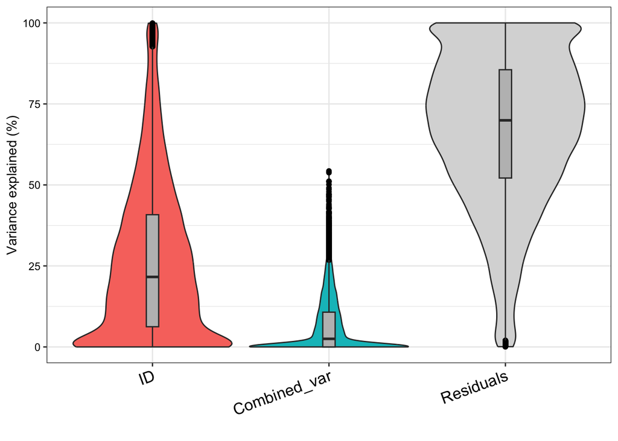

```r
form <- ~ (1 | ID) + (1 | Combined_var)
vp <- fitExtractVarPartModel(vobj, form, phenotype_no_AJ_5)

plotVarPart(sortCols(vp))
```

Comparing p values

```r
# Compare p-values and make plot
p1 <- topTable(fitDupCor, coef = "Combined_varT0_Coconut_oil", number = Inf, sort.by = "none")$P.Value
p2 <- topTable(fitmm, number = Inf, sort.by = "none")$P.Value
```

```
## Removing intercept from test coefficients
```

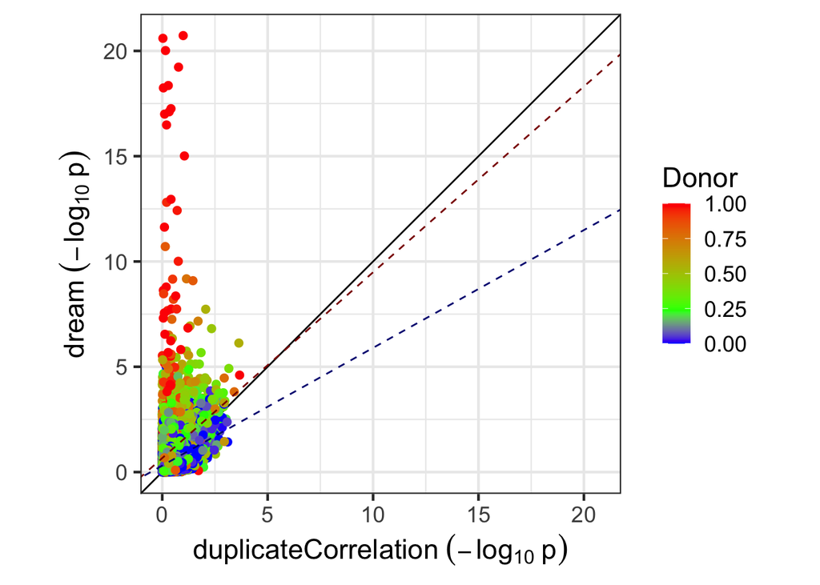

```r
plotCompareP(p1, p2, vp$ID, dupcor$consensus)
```

Write to file the tables

```r
write.table(cornoil_deg_res,file="Cornoil_T4_vs_T0_linear_mixed_model_adjusted_age_gender_BMI_using_dream_and_limma.txt",col.names = T,row.names = T,sep="\t",quote = F)
write.table(butter_deg_res,file="Butter_T4_vs_T0_linear_mixed_model_adjusted_age_gender_BMI_using_dream_and_limma.txt",col.names = T,row.names = T,sep="\t",quote = F)
write.table(flaxseed_deg_res,file="Flaxseed_T4_vs_T0_linear_mixed_model_adjusted_age_gender_BMI_using_dream_and_limma.txt",col.names = T,row.names = T,sep="\t",quote = F)
write.table(coconut_deg_res,file="Coconut_T4_vs_T0_linear_mixed_model_adjusted_age_gender_BMI_using_dream_and_limma.txt",col.names = T,row.names = T,sep="\t",quote = F)
```

```r
pdf(file="Violin_plot_of_variance_fraction_for_each_gene_and_each_variable.pdf")
plotVarPart(sortCols(vp))
dev.off()
```